# Trends in inequalities

Mathijn Wilkens

01 November, 2019

# Introduction

The aim is to do an analysis of variance (ANOVA) for the job quality indexes to find out the proportion of variance explained by the covariates available and relevant in the EWCS. Also, to analyse how much of the variance is associated with each covariate. Finally, to compare this over time to see if certain coviarates have become more or less important in explaining inequalities in job quality indexes. Before all that, the code outputs plots that show the development in the mean and standard deviation over time by different breakdown variables.

# Preparation

Source the Eurofound colours and load packages

Import recoded data created in ‘recode.R’. There is a seperate R code file in the project directory that does some basic recoding of the data and checks what variables are available accross which waves of the survey. This file is the result of that.

```r
load("data/EWCS_recoded.Rda")
```

Defining job quality indexes and covariates depending on the availability

```r
indexes_2005 <- c("physrsk","intensity","skilsdis","timequality","prospects")
indexes_2000 <- c("physrsk","intensity","skilsdis","timequality")

indexes_2005_labels <- c("Physical environment","Intensity","Skills and discretion","Working time quality","Prospects")
indexes_2000_labels <- c("Physical environment","Intensity","Skills and discretion","Working time quality")

covariates_2005 <- c("country","nace","isco","sex","age","educ","wp_size","emp_stat")
covariates_2000 <- c("country","nace","isco","sex","age","wp_size","emp_stat")
covariates_1995 <- c("country","nace","isco","sex","age")

covariates_2005_labels <- c("Country","Sector","Occupation","Sex","Age","Education","Workplace size","Employment status")
covariates_2000_labels <- c("Country","Sector","Occupation","Sex","Age","Workplace size","Employment status")
covariates_1995_labels <- c("Country","Sector","Occupation","Sex","Age")

levels(EWCS$wave) <- c("1995","2000","2005","2010","2015")
```

# Descriptives

Create survey design object for including the weights

```r
svyd <- svydesign(~1, data=EWCS[EWCS$wave!="1995",],weights=EWCS[EWCS$wave!="1995",]$w_time)
```

Plotting the mean and standard deviation per index overall.

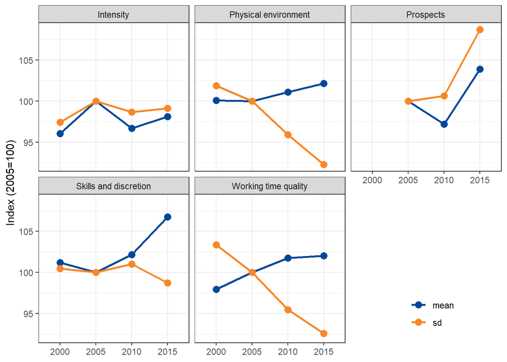

```r
meansd_total <- function(y) {

  x_form <- formula(paste("~wave"))
  y_form <- formula(paste("~",y))

  mean <- svyby(y_form,x_form ,svyd,svymean, na.rm = TRUE) %>%
    rename("mean" = y) %>%
    select(-se)

  sd   <- svyby(y_form,x_form, svyd, svyvar, na.rm = TRUE) %>%
    rename("sd" = y) %>%
    mutate("sd" = sqrt(sd)) %>%
    select(-se)

  df <- left_join(mean, sd, by=c("wave")) %>%
    mutate(mean = mean / mean[wave==2005] * 100,
           sd = sd / sd[wave==2005] * 100) %>%
    reshape2::melt(id=c("wave")) %>%
    filter(value>0)

  return(df)

}

df <- lapply(indexes_2005,meansd_total)
names(df) <- indexes_2005_labels
df <- do.call("rbind",df)
df$index <- sub("\\..*", "", rownames(df))

ggplot(df, aes(x=wave, y=value, colour=variable, group=variable)) +
  facet_wrap(~index) +
  geom_line(size=1) +
  geom_point(size=3) +
  scale_colour_manual(values=EF_2c) +
  ylab("Index (2005=100)") +
  theme_bw() +
    theme(axis.title.x = element_blank(),
          legend.title = element_blank(),
          legend.position = c(0.85,0.1))
```

Function for means and standard deviations with breakdown variables

```r
meansd <- function(y,x) {

  x_form <- formula(paste("~wave+",x))
  y_form <- formula(paste("~",y))

  mean <- svyby(y_form,x_form ,svyd,svymean, na.rm = TRUE) %>%
    rename("mean" = y) %>%
    select(-se)

  sd   <- svyby(y_form,x_form, svyd, svyvar, na.rm = TRUE) %>%
    rename("sd" = y) %>%
    mutate("sd" = sqrt(sd)) %>%
    select(-se)

  df <- left_join(mean, sd, by=c("wave",colnames(mean)[2])) %>%
    reshape2::melt(id=c("wave",colnames(mean)[2])) %>%
    filter(value>0)

  return(df)

}
```

## NACE

Function to plot the indices by variable

```r
plot_function <- function(index,breakdown,num_cols,output_width=8,output_height=5, mean_nudge=0.8, sd_nudge=0.45, round_mean=5, round_sd=2,size_adjustment,legend_height_nudge) {

  #Getting means and standar deviations
  df <- meansd(y=index,x=breakdown)

  #Determining the number of levels of the breakdown variable and splitting them into groups
  num_levels <- length(levels(df[,breakdown]))

  levels_breakdown <- levels(df[,breakdown])

  levels_per_column <- num_levels / num_cols

  #Finding sinsible values for axis
  mround <- function(x,base,dir){

        if (dir=="up") {
          if (x>base*round(x/base)) {
            base*round(x/base)+base
            } else {
            base*round(x/base)
            }
        } else if (dir=="down") {
          if (x<base*round(x/base)) {
            base*round(x/base)-base
            } else {
            base*round(x/base)
            }
        }
  }

  min_mean <- mround(min(df[df$variable=="mean",]$value),round_mean,"down")
  max_mean <- mround(max(df[df$variable=="mean",]$value),round_mean,"up")
  min_sd <- mround(min(df[df$variable=="sd",]$value),round_sd,"down")
  max_sd <- mround(max(df[df$variable=="sd",]$value),round_sd,"up")

  form <- as.formula(paste0("~",breakdown))

  #Plotting the means
  mean_plot <- function(levelselection) {

    ggplot(df[df$variable=="mean" & is.element(df[,breakdown],levelselection),], aes(x=wave,y=value, group=variable)) +
    geom_line(size=1, aes(color="Mean")) +
    geom_point(size=3, aes(color="Mean")) +
    scale_color_manual(values=EF_blue) +
    scale_y_continuous(limits = c(min_mean,max_mean),breaks= scales::pretty_breaks()) +
    theme_bw() +
      theme(axis.title.x = element_blank(),
            axis.title.y = element_blank(),
            panel.grid.minor = element_blank(),
            plot.margin=unit(c(0.1,0,0,0.2), "cm"),
            strip.background = element_blank(),
            strip.text = element_text(hjust=0),
            legend.position = c(mean_nudge,legend_height_nudge),
            legend.title = element_blank(),
            legend.background = element_blank())

  }

  #Plotting the standard deviations
  sd_plot <- function(levelselection) {

    ggplot(df[df$variable=="sd"  & is.element(df[,breakdown],levelselection),], aes(x=wave,y=value, group=variable)) +
    geom_line(size=1, aes(color="Standard deviation")) +
    geom_point(size=3, aes(color="Standard deviation")) +
    scale_color_manual(values=EF_orange) +
    scale_y_continuous(position = "right", limits=c(min_sd,max_sd), breaks= scales::pretty_breaks()) +
    theme_bw() +
      theme(axis.title.x = element_blank(),
            axis.title.y = element_blank(),
            panel.grid.minor = element_blank(),
            plot.margin=unit(c(0.1,0.2,0,0), "cm"),
            strip.background = element_blank(),
            strip.text = element_text(color="white"),
            legend.position = c(sd_nudge,legend_height_nudge),
            legend.title = element_blank(),
            legend.background = element_blank())
  }

  #Collecting the columns
  collection <- NULL

  for (i in 1:num_levels) {

      assign(paste0("p_mean_",i), mean_plot(levels_breakdown[[i]]))
      assign(paste0("p_sd_",i), sd_plot(levels_breakdown[[i]]))


    if ((i!=num_levels & levels_per_column%%1==0) | (levels_per_column%%1!=0 & i!=num_levels-1)) {

      assign(paste0("p_mean_",i), get(paste0("p_mean_",i)) + theme(legend.position = "none"))
      assign(paste0("p_sd_",i)  , get(paste0("p_sd_",i))   + theme(legend.position = "none"))

    }

    if (i<num_levels-num_cols+1)  {

      assign(paste0("p_mean_",i), get(paste0("p_mean_",i)) + theme(axis.text.x  = element_blank(),
                                                                   axis.ticks.x = element_blank()))
      assign(paste0("p_sd_",i), get(paste0("p_sd_",i)) + theme(axis.text.x  = element_blank(),
                                                                   axis.ticks.x = element_blank()))

    } else if (levels_per_column%%1==0 | levels_per_column%%1!=0 & (i==num_levels-1 | i==num_levels)) {

      assign(paste0("p_mean_",i), get(paste0("p_mean_",i)) + theme(plot.margin=unit(c(0.1,0,0.8,0.2), "cm")))
      assign(paste0("p_sd_",i), get(paste0("p_sd_",i))     + theme(plot.margin=unit(c(0.1,0.2,0.8,0), "cm")))

    }

    element <- list(as.name(paste0("p_mean_",i)),as.name(paste0("p_sd_",i)))
    assign(paste0("p_",i), do.call("arrangeGrob", args=c(grobs=element,
                                                           list(nrow=1, top=textGrob(levels_breakdown[[i]],gp=gpar(fontsize=9))))))

    collection <- c(collection,as.name(paste0("p_",i)))


  }

  #If the number of levels cannot be divided with the number of columns, add blank chart to fill it up
  if (levels_per_column%%1!=0) {

    blank <- ggplot()  + theme(panel.background = element_rect(fill="white"),
                               plot.margin=unit(c(0.1,0,0.8,0.2), "cm"))
    element <- list(as.name("blank"),as.name("blank"))
    assign("blank_comb", do.call("arrangeGrob", args=c(grobs=element,list(nrow=1, top=textGrob("",gp=gpar(fontsize=9))))))

    collection <- c(collection,as.name("blank_comb"))

    collection_special <- NULL

    for (i in 1:num_cols) {

    selection <- seq(from=i, to=length(collection) ,by=num_cols)

    heights <- NULL

    if (i!=num_cols) {

      for (j in seq(1:(length(collection)/num_cols)))

        if (j!=length(collection)/num_cols) {

          heights <- c(heights,1)

        } else {

          heights <- c(heights,size_adjustment)

        }

    } else {

      for (j in seq(1:(length(collection)/num_cols)))

        if (j!=length(collection)/num_cols-1) {

          heights <- c(heights,1)

        } else {

          heights <- c(heights,size_adjustment)

        }

    }

    assign(paste0("collection_",i), do.call("arrangeGrob",
                                            args=c(grobs=collection[selection],
                                                   list(ncol=1,heights=heights))))

    collection_special <- c(collection_special,as.name(paste0("collection_",i)))

    }

    collection <- collection_special

    p <- do.call("grid.arrange",args=c(grobs=collection,list(nrow=length(collection)/num_cols)))

  } else {

    heights <- NULL
    for (i in seq(1,length(collection)/num_cols)) {

      if (i!=length(collection)/num_cols) {

        heights <- c(heights,1)

      } else {

        heights <- c(heights,size_adjustment)

      }
    }

    p <- do.call("grid.arrange",args=c(grobs=collection,list(nrow=length(collection)/num_cols,heights=heights)))

  }


  #Write to .eps and to .png
  ggsave(paste0(breakdown,"_",index,".eps"), plot = p, device = "eps", scale=1, path = "plots" ,
        width = output_width, height = output_height, units = "in")

  ggsave(paste0(breakdown,"_",index,".png"), plot = p, device = "png", scale=1, path = "plots" ,
        width = output_width, height = output_height, units = "in")

  }
```

Physical environment

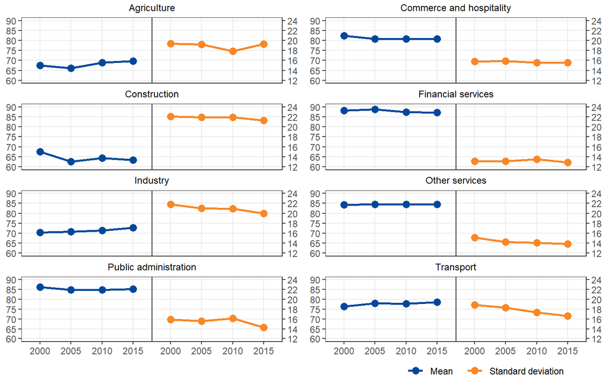

```r
plot_function(index="physrsk",breakdown="nace8",num_cols=2,size_adjustment=1.4,legend_height_nudge=-0.4)
```

Intensity

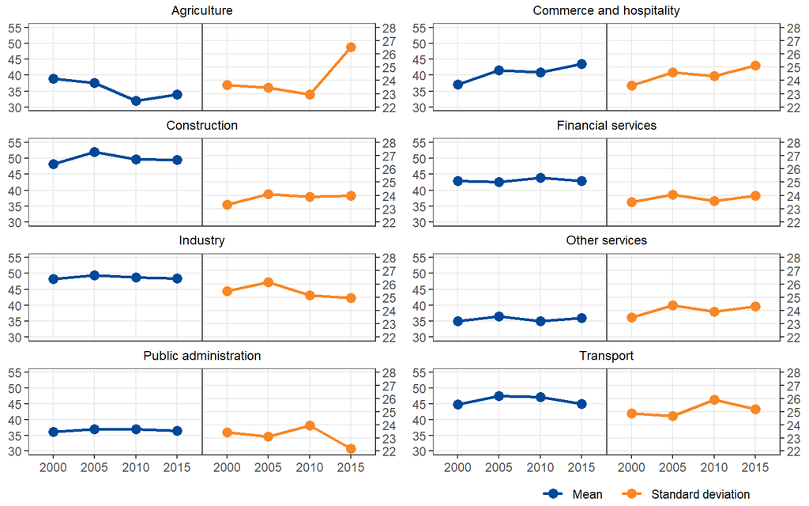

```r
plot_function(index="intensity",breakdown="nace8",num_cols=2,size_adjustment=1.4,legend_height_nudge=-0.4)
```

Skills and discretion

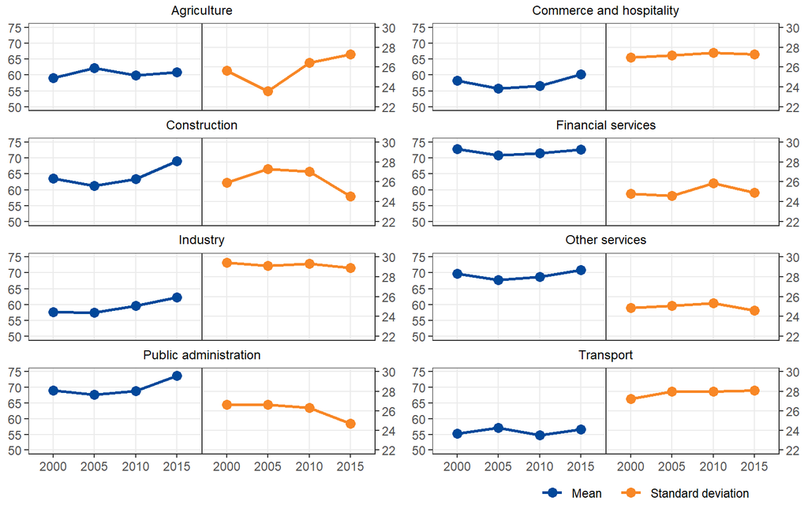

```r
plot_function(index="skilsdis",breakdown="nace8",num_cols=2,size_adjustment=1.4,legend_height_nudge=-0.4)
```

Working time quality

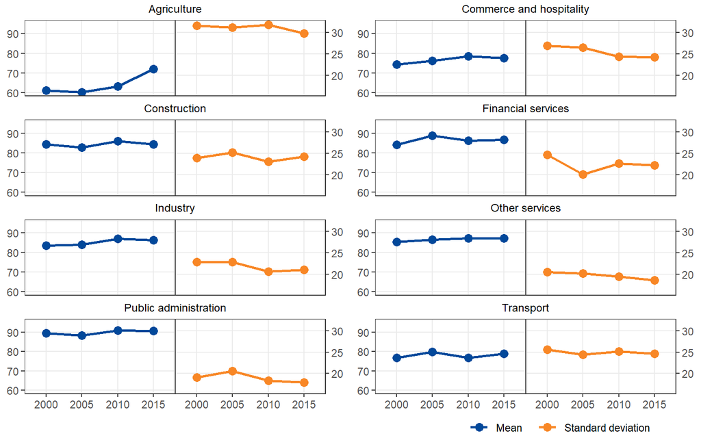

```r
plot_function(index="timequality",breakdown="nace8",num_cols=2,size_adjustment=1.4,legend_height_nudge=-0.4)
```

Job prospects

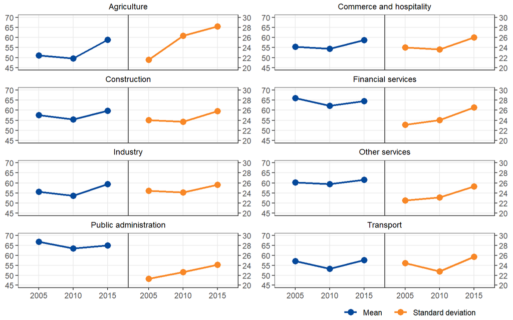

```r
plot_function(index="prospects",breakdown="nace8",num_cols=2,size_adjustment=1.4,legend_height_nudge=-0.4)
```

## ISCO

Exclude armed forces

```r
EWCS_subs <- subset(EWCS, wave!="1995" & isco!="Armed forces")
EWCS_subs$isco <- droplevels(EWCS_subs$isco)
svyd <- svydesign(~1, data=EWCS_subs, weights=EWCS_subs$w_time)
```

Physical risks

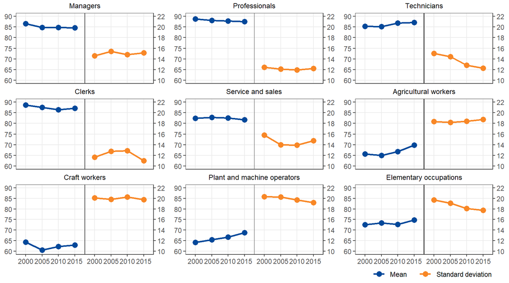

```r
plot_function(index="physrsk",breakdown="isco",num_cols=3, output_width = 9, mean_nudge=0.5, size_adjustment = 1.3, legend_height_nudge=-0.25)
```

Intensity

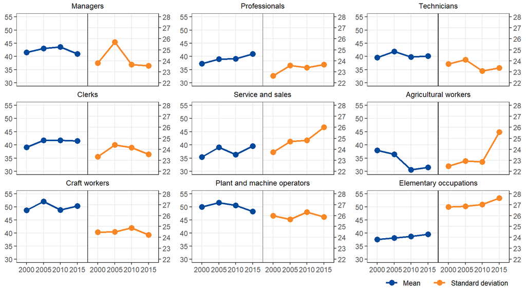

```r
plot_function(index="intensity",breakdown="isco",num_cols=3, output_width = 9, mean_nudge=0.5, size_adjustment = 1.3, legend_height_nudge=-0.25)
```

Skills and discretion

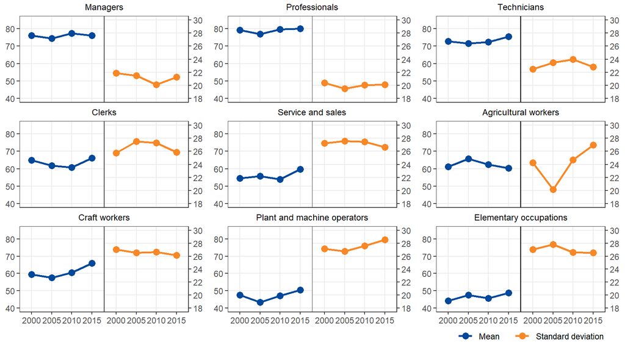

```r
plot_function(index="skilsdis",breakdown="isco",num_cols=3, output_width = 9, mean_nudge=0.5, size_adjustment = 1.3, legend_height_nudge=-0.25)
```

Working time quality

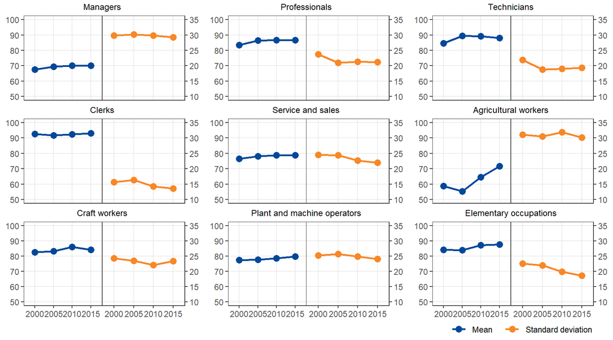

```r
plot_function(index="timequality",breakdown="isco",num_cols=3, output_width = 9, mean_nudge=0.5, size_adjustment = 1.3, legend_height_nudge=-0.25, round_mean=10, round_sd=5)
```

Job prospects

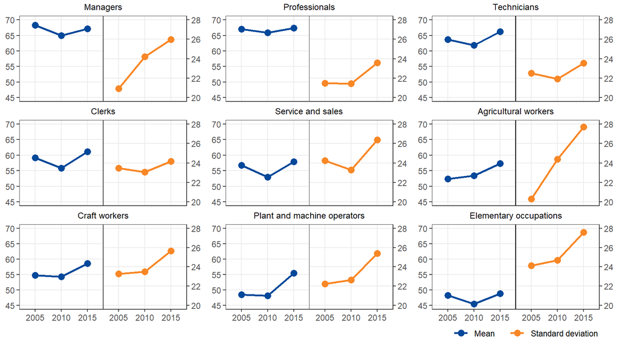

```r
plot_function(index="prospects",breakdown="isco",num_cols=3, output_width = 9, mean_nudge=0.5, size_adjustment = 1.3, legend_height_nudge=-0.25)
```